# Taller de R: Estadística y programación

Lectura 4: Dirty data y Cleaning data (parte 1)

Eduard F. Martínez-González

Universidad de los Andes | [ECON-1302](https://github.com/taller-R)

## Hoy veremos

### **[1.]** Diferencia entre tidy y raw data

### **[2.]** Importar & Exportar (librerías readxl, haven, WriteXLS)

### **[3.]** Importar & Exportar (librería rio)

### **[4.]** Operador pipe (%>%)

### **[5.]** Crear variables

# [1.] Diferencia entre tidy y raw data

## Dirty data es como waldo.

[figure not shown]

Imagen tomada de: [pinterest](https://www.pinterest.pt/pin/543598617520389402/)

## Mas facil cuando esta limpia

[figure not shown]

Imagen tomada de: [pinterest](https://www.pinterest.pt/pin/370632244341806100/)

## De raw data a tidy data

[figure not shown]

Imagen tomada de: [pinterest](https://www.pinterest.pt)

## Workflow data

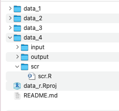

Flujo de trabajo de [Human Rights Data Analysis Group](https://hrdag.org/2016/06/14/the-task-is-a-quantum-of-workflow/)

# [2.] Importar & Exportar (librerías readxl, haven, WriteXLS)

## Importar

- Estas funciones nos permiten importar y exportar bases de datos.

| File_type | Importar | Exportar |
| --- | --- | --- |
| .csv | read.csv() | write.csv() |
| .xls & .xlsx | read_excel() | WriteXLS() |
| .dta | read_dta() | write_dta() |
| RDS | readRDS() | saveRDS() |

## EJ: Importar

- Importar base de datos en formato .dta

```r
data_dta = read_dta(file = "data/input/Area - Caracteristicas generales (Personas).dta")
```

```
## # A tibble: 1 × 4
##   directorio secuencia_p P6020  P6050
##        <dbl>       <dbl> <chr>  <dbl>
## 1     120468           1 hombre     1
```

- Importar base de datos en formato .Rdata

```r
load(file = "data/input/Homicidios 2020.Rdata")
```

```
## # A tibble: 1 × 4
##   departamento municipio    mes   `armas medios`
##   <chr>        <chr>        <chr> <chr>
## 1 AMAZONAS     LETICIA (CT) MARZO ARMA BLANCA / CORTOPUNZANTE
```

## EJ: Exportar

- Exportar base de datos en formato .dta

```r
write_dta(data = data_dta ,path = "data/output/Area - Caracteristicas generales (Personas).dta")
```

- Exportar base de datos en formato .Rdata

```r
save(data_rdata,data_dta,file = "data/output/Datos.Rdata")
```

## Algunos argumentos

Muchos de estas funciones utilizan los mismos argumentos.

- file = "". Direccion de directorio
- sep(“,”) = Permite separar las filas por el argumento.
- skip = #. En cual fila se debe comenzar a leer.
- sheet = #. Cual hoja se debe leer.
- header = T/F. Están los nombres de las columnas presentes.
- skipNul = T/F. Se debe aceptar los no elementos.

# [3.] Importar & Exportar (librería rio)

## Importar

- Rio es un package que simplifica el proceso de importación, exportación e incluso conversion entre formatos.

| File_type | Importar | Exportar |
| --- | --- | --- |
| .csv | Import() | export() |
| .xls & .xlsx | Import() | export() |
| .dta | Import() | export() |
| RDS | Import() | export() |

## EJ: Importar

- Importación en formato .csv

```r
data_csv = import(file = "data/input/censo 2018.csv", skip = 6)
```

```
##   codigo_divipola NOMBRE DEPARTAMENTO poblacion_en_hogares Poblacion_en_lea
## 1              00      Total Nacional             43835324           329093
## 2              05           Antioquia              5931492            43296
```

- Importación en formato .xls

```r
data_xls = import(file = "data/input/hurto-personas-2020_0.xlsx", skip = 9)
```

```
##   DEPARTAMENTO    MUNICIPIO   MES                ARMAS MEDIOS
## 1     AMAZONAS LETICIA (CT) ENERO ARMA BLANCA / CORTOPUNZANTE
## 2     AMAZONAS LETICIA (CT) MARZO ARMA BLANCA / CORTOPUNZANTE
```

## EJ: Exportacion

- Exportacion en formato .csv

```r
export(x = data_csv, file = "data/output/data_csv.csv")
```

- Exportacion en formato .xls

```r
#export(x = data_xls, file = "data/output/data_xls.xlsx")
```

- Le indicamos a la función en que formato queremos que se exporte con .rds, .xlsx, …

```r
export(x = "data_xls", file = "data/output/data_xls_in_rds.rds")
```

## Convertir

- Convert es la combinación de las dos ultimas seciones, esta permite cambiar un file a .xlsx, .rds, .csv, …

convert(in_file = “file path.csv” , out_file = “file path.xlsx”)

convert(in_file = “file path.xlsx” , out_file = “file path.rds”)

## 3.4 head & skimr

- head(), nos permite ver las primeras filas de los datos, es lo que hemos utilizado hasta el momento para ver los datos.

```r
data_xls %>% select(DEPARTAMENTO, MUNICIPIO, MES, `ARMAS MEDIOS` ) %>% head(1)
```

```
##   DEPARTAMENTO    MUNICIPIO   MES                ARMAS MEDIOS
## 1     AMAZONAS LETICIA (CT) ENERO ARMA BLANCA / CORTOPUNZANTE
```

- skim() nos da un resume de la informacion

Data summary

| Name | Piped data |
| --- | --- |
| Number of rows | 9738 |
| Number of columns | 3 |
| _______________________ |  |
| Column type frequency: |  |
| character | 3 |
| ________________________ |  |
| Group variables | None |

**Variable type: character**

| skim_variable | n_missing | complete_rate | min | max | empty | n_unique | whitespace |
| --- | --- | --- | --- | --- | --- | --- | --- |
| DEPARTAMENTO | 0 | 1 | 4 | 229 | 0 | 36 | 0 |
| MUNICIPIO | 5 | 1 | 3 | 27 | 0 | 793 | 0 |
| MES | 4 | 1 | 4 | 7 | 0 | 7 | 0 |

# [4.] Operador pipe (%>%)

## ¿que es pipe?

Pipe es un conector para las funciones dplyr, este nos permite conectar varias funciones.

Shortcut:

- Cmd + Shift + M -> (para Mac)
- Ctrl + Shift + M -> (para windows)

Informacion extra: [Pipe](https://rsanchezs.gitbooks.io/rprogramming/content/chapter9/pipeline.html)

Informacion extra: [funciones dplyr](https://rsanchezs.gitbooks.io/rprogramming/content/chapter9/dplyr.html)

## datos originales

mtcars, datos instalados en la memoria de r

```
##                    mpg cyl disp  hp drat    wt  qsec
## Mazda RX4         21.0   6  160 110 3.90 2.620 16.46
## Mazda RX4 Wag     21.0   6  160 110 3.90 2.875 17.02
## Datsun 710        22.8   4  108  93 3.85 2.320 18.61
## Hornet 4 Drive    21.4   6  258 110 3.08 3.215 19.44
## Hornet Sportabout 18.7   8  360 175 3.15 3.440 17.02
## Valiant           18.1   6  225 105 2.76 3.460 20.22
```

## Funciones sin pipe

seleccionamos unas filas y las arreglamos en forma descendente

```r
mtcars2 = slice(mtcars, 1:3) # selecionamos filas 1:3
mtcars2 = arrange(mtcars2, desc(disp)) # arreglar de mayor a menor segun la variable disp
mtcars2 = filter(mtcars2, disp == 160) ## disp = 160
```

resultados

```
##               mpg cyl disp  hp drat    wt  qsec
## Mazda RX4      21   6  160 110  3.9 2.620 16.46
## Mazda RX4 Wag  21   6  160 110  3.9 2.875 17.02
```

## Funciones con pipe

Pipe permite disminuir las vesces que se llama la base de datos mtcars y ahorrar lineas de texto

```r
mtcars3 = mtcars %>% slice( 1:3) %>%
   arrange(desc(disp)) %>%
   filter(disp == 160)
```

resultados

```
##               mpg cyl disp  hp drat    wt  qsec
## Mazda RX4      21   6  160 110  3.9 2.620 16.46
## Mazda RX4 Wag  21   6  160 110  3.9 2.875 17.02
```

# [5.] Crear variables

## Agregar variables

Podemos agregar y quitar variables de dos maneras, con " $ " una función bases de R o " mutate() " función de dplyr.

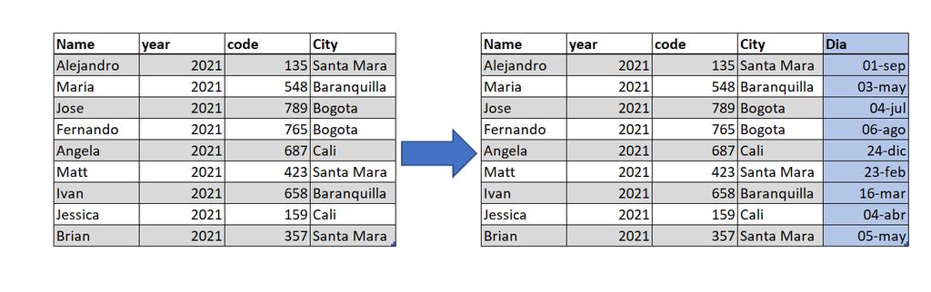

## 5.1 data$var

Utilizando la base de datos mtcars, podemos agregar e eliminar columnas.

```r
mtcars$codigo = paste(mtcars$vs,mtcars$am,mtcars$gear,mtcars$carb) # agregamos columnas

mtcars$vs = NULL # Eliminamos columnas
mtcars$am = NULL
mtcars$gear = NULL
mtcars$carb = NULL
```

```
##                    mpg cyl disp  hp drat    wt  qsec  codigo
## Mazda RX4         21.0   6  160 110 3.90 2.620 16.46 0 1 4 4
## Mazda RX4 Wag     21.0   6  160 110 3.90 2.875 17.02 0 1 4 4
## Datsun 710        22.8   4  108  93 3.85 2.320 18.61 1 1 4 1
## Hornet 4 Drive    21.4   6  258 110 3.08 3.215 19.44 1 0 3 1
## Hornet Sportabout 18.7   8  360 175 3.15 3.440 17.02 0 0 3 2
```

## 5.2 mutate | rnorm | condicionales

podemos obtener el mismo resultado con mutate, pipe, & select:

```r
data("mtcars")
mtcars = mtcars %>% mutate(codigo = paste(vs, am, gear,carb)) %>% select(!c(vs, am, gear, carb))
```

```
##                    mpg cyl disp  hp drat    wt  qsec  codigo
## Mazda RX4         21.0   6  160 110 3.90 2.620 16.46 0 1 4 4
## Mazda RX4 Wag     21.0   6  160 110 3.90 2.875 17.02 0 1 4 4
## Datsun 710        22.8   4  108  93 3.85 2.320 18.61 1 1 4 1
## Hornet 4 Drive    21.4   6  258 110 3.08 3.215 19.44 1 0 3 1
## Hornet Sportabout 18.7   8  360 175 3.15 3.440 17.02 0 0 3 2
```

## rnorm

- rnorm() crea un vector de números aleatorios.

```r
# combinamos con round para obtener 0 digtos despues del punto
round(rnorm(10, mean = 10, sd = 5), digits = 0)
```

```
##  [1] 11 11 15 11 10 15  6  4 16  2
```

- rnorm() con una variable.

```r
x = 10
round(rnorm(x, mean = 10, sd = 5), digits = 0)
```

```
##  [1]  3 11 12 14 11  9 12  7 11 18
```

## condicionales

- Hint por eso el titulo.

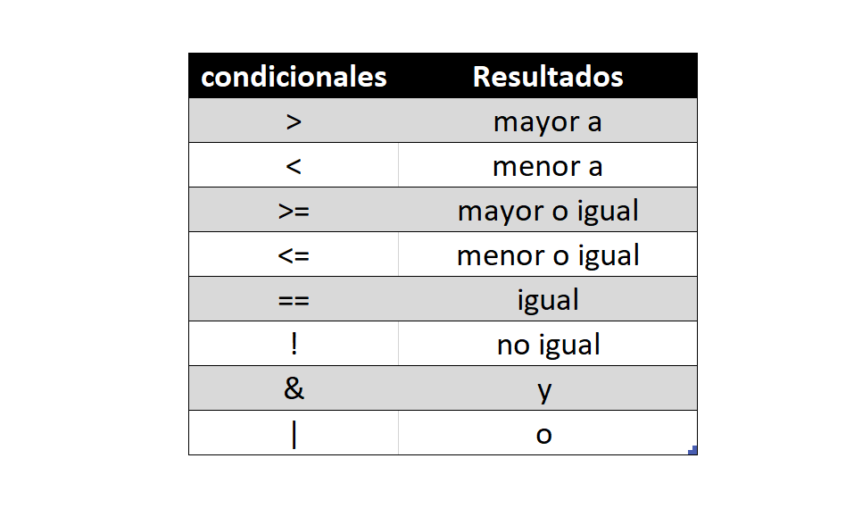

## 5.3 mutate & rnorm & condiconales

- Utilizaremos la base de datos iris, viene en la memoria de r.

```
##     Sepal.Length Sepal.Width Petal.Length Petal.Width    Species
## 1            5.1         3.5          1.4         0.2     setosa
## 2            4.9         3.0          1.4         0.2     setosa
## 3            4.7         3.2          1.3         0.2     setosa
## 4            4.6         3.1          1.5         0.2     setosa
## 5            5.0         3.6          1.4         0.2     setosa
## 6            5.4         3.9          1.7         0.4     setosa
## 7            4.6         3.4          1.4         0.3     setosa
## 8            5.0         3.4          1.5         0.2     setosa
## 9            4.4         2.9          1.4         0.2     setosa
## 10           4.9         3.1          1.5         0.1     setosa
## 11           5.4         3.7          1.5         0.2     setosa
## 12           4.8         3.4          1.6         0.2     setosa
## 13           4.8         3.0          1.4         0.1     setosa
## 14           4.3         3.0          1.1         0.1     setosa
```

[output cut: 136 more lines]

## mutate & rnorm

- Creamos un vector random

```r
# numero aleatorio. utilizo las filas de iris como el vector de numeros
ran = round(rnorm(nrow(iris), mean = 10, sd = 5), digits = 1)
```

```
##  [1] 11.4  8.5 11.7  8.3  7.6  1.2 16.3 11.9  6.2  9.0
```

- Creamos una nueva columna

```r
# nueva columna con numeroa aleatorio
 iris %>% mutate(r_num = ran) %>%  head( 5)
```

```
##   Sepal.Length Sepal.Width Petal.Length Petal.Width Species r_num
## 1          5.1         3.5          1.4         0.2  setosa  11.4
## 2          4.9         3.0          1.4         0.2  setosa   8.5
## 3          4.7         3.2          1.3         0.2  setosa  11.7
## 4          4.6         3.1          1.5         0.2  setosa   8.3
## 5          5.0         3.6          1.4         0.2  setosa   7.6
```

## mutate & rnorm & condiconales

EJ 1: Usando rnum para filtrar iris

```r
# filtramos por species == c("virginica" o "setosa") y el numero ran 15 <= # >=10.
iris %>%
   mutate(r_num = ran) %>%
   filter( Species == "virginica" | Species == "setosa" & r_num >= 10 & r_num <= 15 ) %>%
   select(!c(Sepal.Length)) # para visualizar la tabla mejor
```

```
##    Sepal.Width Petal.Length Petal.Width   Species r_num
## 1          3.5          1.4         0.2    setosa  11.4
## 2          3.2          1.3         0.2    setosa  11.7
## 3          3.4          1.5         0.2    setosa  11.9
## 4          3.4          1.6         0.2    setosa  13.0
## 5          4.0          1.2         0.2    setosa  12.5
## 6          3.9          1.3         0.4    setosa  12.1
## 7          3.8          1.7         0.3    setosa  10.3
## 8          3.8          1.5         0.3    setosa  10.5
## 9          3.3          1.7         0.5    setosa  11.6
## 10         3.4          1.6         0.4    setosa  10.3
## 11         3.1          1.6         0.2    setosa  10.2
## 12         4.1          1.5         0.1    setosa  12.2
## 13         3.1          1.5         0.2    setosa  12.9
## 14         3.5          1.3         0.2    setosa  12.4
```

[output cut: 56 more lines]

## mutate & condiconales

EJ 2: Usando condicionales para crear nuevas varaibles de iris

```r
iris %>%  # copiamos los anchos de (setosa) a su propia columna
  mutate(setosa.p.w = ifelse(test = Species =="setosa", yes = Petal.Width, no = NA)) %>%
  # copiamos los anchos que no sean (setosa y versicolor) a su propia columna
  mutate(virginica.p.w = ifelse(test = Species !="setosa" & Species !="versicolor", yes = Petal.Width, no = NA))%>%
  # para visualizar la tabla mejor
   select(!c(Sepal.Length, Sepal.Width,Petal.Length))
```

```
##     Petal.Width    Species setosa.p.w virginica.p.w
## 1           0.2     setosa        0.2            NA
## 2           0.2     setosa        0.2            NA
## 3           0.2     setosa        0.2            NA
## 4           0.2     setosa        0.2            NA
## 5           0.2     setosa        0.2            NA
## 6           0.4     setosa        0.4            NA
## 7           0.3     setosa        0.3            NA
## 8           0.2     setosa        0.2            NA
## 9           0.2     setosa        0.2            NA
## 10          0.1     setosa        0.1            NA
## 11          0.2     setosa        0.2            NA
## 12          0.2     setosa        0.2            NA
## 13          0.1     setosa        0.1            NA
## 14          0.1     setosa        0.1            NA
```

[output cut: 136 more lines]

# Hoy vimos…

☑ Diferencia entre tidy y raw data

☑ importar & Exportar con; readxl, haven, WriteXLS

☑ importar & Exportar con; rio

☑ Operador pipe ( %>% )

☑ Crear variables